# 第2章 資料清理與轉換(tidyverse)

## 填補遺漏值

### 方法一：平均數

```r
df$Luggage.room[is.na(df$Luggage.room)] <- mean(df$Luggage.room, na.rm = TRUE)
colSums(is.na(df)) # Luggage.room 欄位已經沒有遺漏值
```

```
##       Manufacturer              Model               Type          Min.Price
##                  0                  0                  0                  0
##              Price          Max.Price           MPG.city        MPG.highway
##                  0                  0                  0                  0
##            AirBags         DriveTrain          Cylinders         EngineSize
##                  0                  0                  0                  0
##         Horsepower                RPM       Rev.per.mile    Man.trans.avail
##                  0                  0                  0                  0
## Fuel.tank.capacity         Passengers             Length          Wheelbase
##                  0                  0                  0                  0
##              Width        Turn.circle     Rear.seat.room       Luggage.room
##                  0                  0                  2                  0
##             Weight             Origin               Make
##                  0                  0                  0
```

### 方法二：中位數

```r
df$Rear.seat.room <- median(df$Rear.seat.room, na.rm = TRUE)
sum(is.na(df[,'Rear.seat.room']))
```

```
## [1] 0
```

### 方法三：固定值

```r
# replace_na {tidyr}
```

## 2.重複值(Duplicate Records)

範例：

Bob 有重複。

| ID | Name | Gender | Math | English |
| --- | --- | --- | --- | --- |
| 1 | ALAN | F | 95 | 80 |
| 2 | BOB | M | 70 | 85 |
| 2 | BOB | M | 70 | 85 |
| 4 | DAVID | M | 90 | 77 |

```r
df <- data.frame(
  ID      = c(1, 2, 2, 4),
  Name    = c("ALAN", "BOB", "BOB", "DAVID"),
  Gender  = c("F", "M", "M", "M"),
  Math    = c(95, 70, 70, 90),
  English = c(80, 85, 85, 77)
)
df
```

| ID | Name | Gender | Math | English |
| --- | --- | --- | --- | --- |
| 1 | ALAN | F | 95 | 80 |
| 2 | BOB | M | 70 | 85 |
| 2 | BOB | M | 70 | 85 |
| 4 | DAVID | M | 90 | 77 |

### 找出重複資料列

```r
duplicated(df)
```

```
## [1] FALSE FALSE  TRUE FALSE
```

### 查看重複資料

```r
df[duplicated(df), ]
```

|  | ID | Name | Gender | Math | English |
| --- | --- | --- | --- | --- | --- |
| 3 | 2 | BOB | M | 70 | 85 |

### 刪除重複資料列

```r
unique(df)
```

|  | ID | Name | Gender | Math | English |
| --- | --- | --- | --- | --- | --- |
| 1 | 1 | ALAN | F | 95 | 80 |
| 2 | 2 | BOB | M | 70 | 85 |
| 4 | 4 | DAVID | M | 90 | 77 |

### 刪除重複資料列 {dplyr}

```r
library(dplyr)
distinct(df)
```

| ID | Name | Gender | Math | English |
| --- | --- | --- | --- | --- |
| 1 | ALAN | F | 95 | 80 |
| 2 | BOB | M | 70 | 85 |
| 4 | DAVID | M | 90 | 77 |

## 3.資料型態錯誤(Incorrect Data Types)

### 常見資料型態錯誤

| 問題 | 常見原因 | 解決方式 |
| --- | --- | --- |
| 數值變成文字 (character) | Excel混入文字、單位 | as.numeric() |
| 日期變成文字 | CSV匯入 | as.Date() |
| 類別變成文字 | 性別、縣市 | factor() |
| 一欄存多個資訊 | “男,25” | separate() |
| 多欄代表同一變數 | Jan、Feb、Mar | pivot_longer() |
| 一欄混合不同型態 | “100kg” | 去除單位再轉型 |
| 缺失值表示方式不一致 | ““,”-“,”NA” | 統一成 NA |
| 重複資料 | 匯入重覆 | distinct() |
| 欄名不一致 | Age、AGE、age | rename() |

- 字串轉換為數值: df$Column <- as.numeric(df$Column)
- 數值轉換為字串: df$Column <- as.character(df$Column)
- 字串轉換為日期: df$Column <- as.Date(df$Column)

### 字串轉換為日期

```r
tmp <- as.Date("31/08/2026", format="%d/%m/%Y")
print(tmp)
```

```
## [1] "2026-08-31"
```

```r
class(tmp)
```

```
## [1] "Date"
```

### 字串轉換為因子 (Factor)

```r
# df$Column <- as.factor(df$Column)
```

### 因子轉換字串

```r
# df$Column <- as.character(df$Column)
```

# 🌸 2.2 dplyr：filter/select/mutate/summarise/group_by

## 管線運算子(`%>%`)

- magrittr 套件中主要的功能是提供 `%>%` 管線運算子(Pipe Operator)
- 管線運算子使用 ‘|>’或’%>%’ 是一種將前一個指令或函數的輸出結果(output), 直接傳遞給下一個函數作為輸入的工具(input), 即做為右側函數的第一個參數輸入.
- 它能讓程式碼由左至右、由上而下順暢閱讀, 提升可讀性避免多層巢狀括號的混亂.
- 管線運算子能減少暫存變數, 不需要為每一個中間步驟宣告額外的變數.
- RStudio Global Options Tools Code Editing: [Use native pipe operator,|> (requires R 4.1+)] 打勾
- CRAN magrittr 套件: https://cran.r-project.org/web/packages/magrittr/index.html
- magrittr 套件簡介: https://cran.r-project.org/web/packages/magrittr/vignettes/magrittr.html
- magrittr 套件範例

```r
# 1加侖 = 3.785公升
# 1公里 = 0.621371192 英里
# 原資料: miles per gallon
# 新資料: kilometers per liter
# 新資料 = miles per gallon*((1/0.621371192)/3.785)=0.42519

library(magrittr)

car_data <-
  mtcars %>%
  subset(hp > 100) %>%
  aggregate(. ~ cyl, data = ., FUN = . %>% mean %>% round(2)) %>%
  transform(kpl = mpg %>% multiply_by(0.4251)) %>%
  print
```

```
##   cyl   mpg   disp     hp drat   wt  qsec   vs   am gear carb       kpl
## 1   4 25.90 108.05 111.00 3.94 2.15 17.75 1.00 1.00 4.50 2.00 11.010090
## 2   6 19.74 183.31 122.29 3.59 3.12 17.98 0.57 0.43 3.86 3.43  8.391474
## 3   8 15.10 353.10 209.21 3.23 4.00 16.77 0.00 0.14 3.29 3.50  6.419010
```

## 認識dplyr套件

- r cran dplyr: https://cran.r-project.org/web/packages/dplyr/index.html
- dplyr: A Grammar of Data Manipulation 資料操作文法
- dplyr = data frame + plyr
- plyr 發音 plier (鉗子), plyr 是 dplyr 的前個套件版本, 作者推薦使用 dplyr 套件
- plyr: https://www.slideshare.net/hadley/plyr-one-data-analytic-strategy

## flights 2013年NYC機場航班資料, 33萬筆資料

```r
library(dplyr)
library(nycflights13)
```

```r
data(flights) # tibble: 336776*19
print(flights)
```

```
## # A tibble: 336,776 × 19
##     year month   day dep_time sched_dep_time dep_delay arr_time sched_arr_time
##    <int> <int> <int>    <int>          <int>     <dbl>    <int>          <int>
##  1  2013     1     1      517            515         2      830            819
##  2  2013     1     1      533            529         4      850            830
##  3  2013     1     1      542            540         2      923            850
##  4  2013     1     1      544            545        -1     1004           1022
##  5  2013     1     1      554            600        -6      812            837
##  6  2013     1     1      554            558        -4      740            728
##  7  2013     1     1      555            600        -5      913            854
##  8  2013     1     1      557            600        -3      709            723
##  9  2013     1     1      557            600        -3      838            846
## 10  2013     1     1      558            600        -2      753            745
## # ℹ 336,766 more rows
## # ℹ 11 more variables: arr_delay <dbl>, carrier <chr>, flight <int>,
## #   tailnum <chr>, origin <chr>, dest <chr>, air_time <dbl>, distance <dbl>,
## #   hour <dbl>, minute <dbl>, time_hour <dttm>
```

```r
class(flights) # "tbl_df" "tbl" "data.frame"
```

```
## [1] "tbl_df"     "tbl"        "data.frame"
```

- flights 資料集變數說明

| 變數 | 資料型態 | 中文說明 | 範例 |
| --- | --- | --- | --- |
| year | integer | 年份 | 2013 |
| month | integer | 月份 | 1~12 |
| day | integer | 日期 | 1~31 |
| dep_time | integer | 實際起飛時間(HHMM) | 517(表示05:17), NA取消 |
| sched_dep_time | integer | 表定起飛時間(HHMM) | 515 |
| dep_delay | double | 起飛延誤(分鐘) | 2、-5、60 |
| arr_time | integer | 實際抵達時間(HHMM) | 830 |
| sched_arr_time | integer | 表定抵達時間(HHMM) | 819 |
| arr_delay | double | 抵達延誤(分鐘) | 11、-20 |
| carrier | character | 航空公司代碼 | AA、DL |
| flight | integer | 航班編號 | 1545 |
| tailnum | character | 飛機註冊編號 | N14228 |
| origin | character | 起飛機場 | JFK |
| dest | character | 目的地機場 | LAX |
| air_time | double | 飛行時間(分鐘) | 150 |
| distance | double | 飛行距離(英里) | 950 |
| hour | double | 表定起飛小時 | 5 |
| min | double | 表定起飛分鐘 | 15 |
| time_hour | POSIXct | 日期時間(UTC) | 2013-01-01 05:00 |

- dep_delay:
  - dep_delay 起飛延誤 = 實際起飛 - 表定起飛
  - -10: 提早10分鐘
  - 0: 準時
  - 15: 延誤15分鐘
  - 120: 延誤2小時
- arr_delay:
  - arr_delay 抵達延誤 = 實際抵達 - 表定抵達, **抵達延誤可用於分析航班績效重要的變數**
  - 11: 晚11分鐘抵達
  - -20: 提早20分鐘抵達
- 資料檢視函數,快速查看資料框（data.frame 或 tibble）的結構.

```r
glimpse(flights)
```

```
## Rows: 336,776
## Columns: 19
## $ year           <int> 2013, 2013, 2013, 2013, 2013, 2013, 2013, 2013, 2013, 2…
## $ month          <int> 1, 1, 1, 1, 1, 1, 1, 1, 1, 1, 1, 1, 1, 1, 1, 1, 1, 1, 1…
## $ day            <int> 1, 1, 1, 1, 1, 1, 1, 1, 1, 1, 1, 1, 1, 1, 1, 1, 1, 1, 1…
## $ dep_time       <int> 517, 533, 542, 544, 554, 554, 555, 557, 557, 558, 558, …
## $ sched_dep_time <int> 515, 529, 540, 545, 600, 558, 600, 600, 600, 600, 600, …
## $ dep_delay      <dbl> 2, 4, 2, -1, -6, -4, -5, -3, -3, -2, -2, -2, -2, -2, -1…
## $ arr_time       <int> 830, 850, 923, 1004, 812, 740, 913, 709, 838, 753, 849,…
## $ sched_arr_time <int> 819, 830, 850, 1022, 837, 728, 854, 723, 846, 745, 851,…
## $ arr_delay      <dbl> 11, 20, 33, -18, -25, 12, 19, -14, -8, 8, -2, -3, 7, -1…
## $ carrier        <chr> "UA", "UA", "AA", "B6", "DL", "UA", "B6", "EV", "B6", "…
## $ flight         <int> 1545, 1714, 1141, 725, 461, 1696, 507, 5708, 79, 301, 4…
## $ tailnum        <chr> "N14228", "N24211", "N619AA", "N804JB", "N668DN", "N394…
## $ origin         <chr> "EWR", "LGA", "JFK", "JFK", "LGA", "EWR", "EWR", "LGA",…
## $ dest           <chr> "IAH", "IAH", "MIA", "BQN", "ATL", "ORD", "FLL", "IAD",…
## $ air_time       <dbl> 227, 227, 160, 183, 116, 150, 158, 53, 140, 138, 149, 1…
## $ distance       <dbl> 1400, 1416, 1089, 1576, 762, 719, 1065, 229, 944, 733, …
## $ hour           <dbl> 5, 5, 5, 5, 6, 5, 6, 6, 6, 6, 6, 6, 6, 6, 6, 5, 6, 6, 6…
## $ minute         <dbl> 15, 29, 40, 45, 0, 58, 0, 0, 0, 0, 0, 0, 0, 0, 0, 59, 0…
## $ time_hour      <dttm> 2013-01-01 05:00:00, 2013-01-01 05:00:00, 2013-01-01 0…
```

- 資料結構

```r
str(flights)
```

```
## tibble [336,776 × 19] (S3: tbl_df/tbl/data.frame)
##  $ year          : int [1:336776] 2013 2013 2013 2013 2013 2013 2013 2013 2013 2013 ...
##  $ month         : int [1:336776] 1 1 1 1 1 1 1 1 1 1 ...
##  $ day           : int [1:336776] 1 1 1 1 1 1 1 1 1 1 ...
##  $ dep_time      : int [1:336776] 517 533 542 544 554 554 555 557 557 558 ...
##  $ sched_dep_time: int [1:336776] 515 529 540 545 600 558 600 600 600 600 ...
##  $ dep_delay     : num [1:336776] 2 4 2 -1 -6 -4 -5 -3 -3 -2 ...
##  $ arr_time      : int [1:336776] 830 850 923 1004 812 740 913 709 838 753 ...
##  $ sched_arr_time: int [1:336776] 819 830 850 1022 837 728 854 723 846 745 ...
##  $ arr_delay     : num [1:336776] 11 20 33 -18 -25 12 19 -14 -8 8 ...
##  $ carrier       : chr [1:336776] "UA" "UA" "AA" "B6" ...
##  $ flight        : int [1:336776] 1545 1714 1141 725 461 1696 507 5708 79 301 ...
##  $ tailnum       : chr [1:336776] "N14228" "N24211" "N619AA" "N804JB" ...
##  $ origin        : chr [1:336776] "EWR" "LGA" "JFK" "JFK" ...
##  $ dest          : chr [1:336776] "IAH" "IAH" "MIA" "BQN" ...
##  $ air_time      : num [1:336776] 227 227 160 183 116 150 158 53 140 138 ...
##  $ distance      : num [1:336776] 1400 1416 1089 1576 762 ...
##  $ hour          : num [1:336776] 5 5 5 5 6 5 6 6 6 6 ...
##  $ minute        : num [1:336776] 15 29 40 45 0 58 0 0 0 0 ...
##  $ time_hour     : POSIXct[1:336776], format: "2013-01-01 05:00:00" "2013-01-01 05:00:00" ...
```

- 資料摘要

```r
summary(flights) # 有NA
```

```
##       year          month             day           dep_time    sched_dep_time
##  Min.   :2013   Min.   : 1.000   Min.   : 1.00   Min.   :   1   Min.   : 106
##  1st Qu.:2013   1st Qu.: 4.000   1st Qu.: 8.00   1st Qu.: 907   1st Qu.: 906
##  Median :2013   Median : 7.000   Median :16.00   Median :1401   Median :1359
##  Mean   :2013   Mean   : 6.549   Mean   :15.71   Mean   :1349   Mean   :1344
##  3rd Qu.:2013   3rd Qu.:10.000   3rd Qu.:23.00   3rd Qu.:1744   3rd Qu.:1729
##  Max.   :2013   Max.   :12.000   Max.   :31.00   Max.   :2400   Max.   :2359
##                                                  NAs    :8255
##    dep_delay          arr_time    sched_arr_time   arr_delay
##  Min.   : -43.00   Min.   :   1   Min.   :   1   Min.   : -86.000
##  1st Qu.:  -5.00   1st Qu.:1104   1st Qu.:1124   1st Qu.: -17.000
##  Median :  -2.00   Median :1535   Median :1556   Median :  -5.000
##  Mean   :  12.64   Mean   :1502   Mean   :1536   Mean   :   6.895
##  3rd Qu.:  11.00   3rd Qu.:1940   3rd Qu.:1945   3rd Qu.:  14.000
##  Max.   :1301.00   Max.   :2400   Max.   :2359   Max.   :1272.000
##  NAs    :8255      NAs    :8713                  NAs    :9430
##       carrier           flight          tailnum             origin
##  Length   :336776   Min.   :   1   Length   :336776   Length   :336776
##  N.unique :    16   1st Qu.: 553   N.unique :  4043   N.unique :     3
##  N.blank  :     0   Median :1496   N.blank  :     0   N.blank  :     0
##  Min.nchar:     2   Mean   :1972   Min.nchar:     5   Min.nchar:     3
##  Max.nchar:     2   3rd Qu.:3465   Max.nchar:     6   Max.nchar:     3
##                     Max.   :8500   NAs      :  2512
##
##         dest           air_time        distance         hour
##  Length   :336776   Min.   : 20.0   Min.   :  17   Min.   : 1.00
##  N.unique :   105   1st Qu.: 82.0   1st Qu.: 502   1st Qu.: 9.00
##  N.blank  :     0   Median :129.0   Median : 872   Median :13.00
##  Min.nchar:     3   Mean   :150.7   Mean   :1040   Mean   :13.18
##  Max.nchar:     3   3rd Qu.:192.0   3rd Qu.:1389   3rd Qu.:17.00
##                     Max.   :695.0   Max.   :4983   Max.   :23.00
##                     NAs    :9430
##      minute        time_hour
##  Min.   : 0.00   Min.   :2013-01-01 05:00:00
##  1st Qu.: 8.00   1st Qu.:2013-04-04 13:00:00
##  Median :29.00   Median :2013-07-03 10:00:00
##  Mean   :26.23   Mean   :2013-07-03 05:22:54
##  3rd Qu.:44.00   3rd Qu.:2013-10-01 07:00:00
##  Max.   :59.00   Max.   :2013-12-31 23:00:00
##
```

- 如何轉換為 tbl_df, 使用 tibble::as.tbl

```r
mytbl <- tibble::as_tibble(iris)
class(mytbl)
```

```
## [1] "tbl_df"     "tbl"        "data.frame"
```

- 前6筆資料

```r
head(flights)
```

| year | month | day | dep_time | sched_dep_time | dep_delay | arr_time | sched_arr_time | arr_delay | carrier | flight | tailnum | origin | dest | air_time | distance | hour | minute | time_hour |
| --- | --- | --- | --- | --- | --- | --- | --- | --- | --- | --- | --- | --- | --- | --- | --- | --- | --- | --- |
| 2013 | 1 | 1 | 517 | 515 | 2 | 830 | 819 | 11 | UA | 1545 | N14228 | EWR | IAH | 227 | 1400 | 5 | 15 | 2013-01-01 05:00:00 |
| 2013 | 1 | 1 | 533 | 529 | 4 | 850 | 830 | 20 | UA | 1714 | N24211 | LGA | IAH | 227 | 1416 | 5 | 29 | 2013-01-01 05:00:00 |
| 2013 | 1 | 1 | 542 | 540 | 2 | 923 | 850 | 33 | AA | 1141 | N619AA | JFK | MIA | 160 | 1089 | 5 | 40 | 2013-01-01 05:00:00 |
| 2013 | 1 | 1 | 544 | 545 | -1 | 1004 | 1022 | -18 | B6 | 725 | N804JB | JFK | BQN | 183 | 1576 | 5 | 45 | 2013-01-01 05:00:00 |
| 2013 | 1 | 1 | 554 | 600 | -6 | 812 | 837 | -25 | DL | 461 | N668DN | LGA | ATL | 116 | 762 | 6 | 0 | 2013-01-01 06:00:00 |
| 2013 | 1 | 1 | 554 | 558 | -4 | 740 | 728 | 12 | UA | 1696 | N39463 | EWR | ORD | 150 | 719 | 5 | 58 | 2013-01-01 05:00:00 |

- 後6筆資料

```r
# 注意:資料最後日期為12月31日, 但資料排序不是依照月,日排序, 最後一筆是9月30日
tail(flights)
```

| year | month | day | dep_time | sched_dep_time | dep_delay | arr_time | sched_arr_time | arr_delay | carrier | flight | tailnum | origin | dest | air_time | distance | hour | minute | time_hour |
| --- | --- | --- | --- | --- | --- | --- | --- | --- | --- | --- | --- | --- | --- | --- | --- | --- | --- | --- |
| 2013 | 9 | 30 | NA | 1842 | NA | NA | 2019 | NA | EV | 5274 | N740EV | LGA | BNA | NA | 764 | 18 | 42 | 2013-09-30 18:00:00 |
| 2013 | 9 | 30 | NA | 1455 | NA | NA | 1634 | NA | 9E | 3393 | NA | JFK | DCA | NA | 213 | 14 | 55 | 2013-09-30 14:00:00 |
| 2013 | 9 | 30 | NA | 2200 | NA | NA | 2312 | NA | 9E | 3525 | NA | LGA | SYR | NA | 198 | 22 | 0 | 2013-09-30 22:00:00 |
| 2013 | 9 | 30 | NA | 1210 | NA | NA | 1330 | NA | MQ | 3461 | N535MQ | LGA | BNA | NA | 764 | 12 | 10 | 2013-09-30 12:00:00 |
| 2013 | 9 | 30 | NA | 1159 | NA | NA | 1344 | NA | MQ | 3572 | N511MQ | LGA | CLE | NA | 419 | 11 | 59 | 2013-09-30 11:00:00 |
| 2013 | 9 | 30 | NA | 840 | NA | NA | 1020 | NA | MQ | 3531 | N839MQ | LGA | RDU | NA | 431 | 8 | 40 | 2013-09-30 08:00:00 |

## dplyr 套件重要函數

| 函數 | 說明 |
| --- | --- |
| filter | 條件式篩選資料 |
| slice | 列的指標篩選資料 |
| arrange | 排序 |
| select | 選取行/更改欄位名稱 |
| rename | 選取所有行/更改欄位名稱 |
| distinct | 選取不重覆資料 |
| mutate | 新增欄位,保留原資料 |
| transmute | 新增欄位,不保留原資料 |
| summarise | 群組計算 |

### filter 條件式篩選資料

```r
filter(flights, month == 1, day == 1)
```

| year | month | day | dep_time | sched_dep_time | dep_delay | arr_time | sched_arr_time | arr_delay | carrier | flight | tailnum | origin | dest | air_time | distance | hour | minute | time_hour |
| --- | --- | --- | --- | --- | --- | --- | --- | --- | --- | --- | --- | --- | --- | --- | --- | --- | --- | --- |
| 2013 | 1 | 1 | 517 | 515 | 2 | 830 | 819 | 11 | UA | 1545 | N14228 | EWR | IAH | 227 | 1400 | 5 | 15 | 2013-01-01 05:00:00 |
| 2013 | 1 | 1 | 533 | 529 | 4 | 850 | 830 | 20 | UA | 1714 | N24211 | LGA | IAH | 227 | 1416 | 5 | 29 | 2013-01-01 05:00:00 |
| 2013 | 1 | 1 | 542 | 540 | 2 | 923 | 850 | 33 | AA | 1141 | N619AA | JFK | MIA | 160 | 1089 | 5 | 40 | 2013-01-01 05:00:00 |
| 2013 | 1 | 1 | 544 | 545 | -1 | 1004 | 1022 | -18 | B6 | 725 | N804JB | JFK | BQN | 183 | 1576 | 5 | 45 | 2013-01-01 05:00:00 |
| 2013 | 1 | 1 | 554 | 600 | -6 | 812 | 837 | -25 | DL | 461 | N668DN | LGA | ATL | 116 | 762 | 6 | 0 | 2013-01-01 06:00:00 |
| 2013 | 1 | 1 | 554 | 558 | -4 | 740 | 728 | 12 | UA | 1696 | N39463 | EWR | ORD | 150 | 719 | 5 | 58 | 2013-01-01 05:00:00 |
| 2013 | 1 | 1 | 555 | 600 | -5 | 913 | 854 | 19 | B6 | 507 | N516JB | EWR | FLL | 158 | 1065 | 6 | 0 | 2013-01-01 06:00:00 |
| 2013 | 1 | 1 | 557 | 600 | -3 | 709 | 723 | -14 | EV | 5708 | N829AS | LGA | IAD | 53 | 229 | 6 | 0 | 2013-01-01 06:00:00 |
| 2013 | 1 | 1 | 557 | 600 | -3 | 838 | 846 | -8 | B6 | 79 | N593JB | JFK | MCO | 140 | 944 | 6 | 0 | 2013-01-01 06:00:00 |
| 2013 | 1 | 1 | 558 | 600 | -2 | 753 | 745 | 8 | AA | 301 | N3ALAA | LGA | ORD | 138 | 733 | 6 | 0 | 2013-01-01 06:00:00 |

[output cut: 832 more lines]

```r
flights[flights$month == 1 & flights$day == 1, ] # 基本指令, same as filter
```

| year | month | day | dep_time | sched_dep_time | dep_delay | arr_time | sched_arr_time | arr_delay | carrier | flight | tailnum | origin | dest | air_time | distance | hour | minute | time_hour |
| --- | --- | --- | --- | --- | --- | --- | --- | --- | --- | --- | --- | --- | --- | --- | --- | --- | --- | --- |
| 2013 | 1 | 1 | 517 | 515 | 2 | 830 | 819 | 11 | UA | 1545 | N14228 | EWR | IAH | 227 | 1400 | 5 | 15 | 2013-01-01 05:00:00 |
| 2013 | 1 | 1 | 533 | 529 | 4 | 850 | 830 | 20 | UA | 1714 | N24211 | LGA | IAH | 227 | 1416 | 5 | 29 | 2013-01-01 05:00:00 |
| 2013 | 1 | 1 | 542 | 540 | 2 | 923 | 850 | 33 | AA | 1141 | N619AA | JFK | MIA | 160 | 1089 | 5 | 40 | 2013-01-01 05:00:00 |
| 2013 | 1 | 1 | 544 | 545 | -1 | 1004 | 1022 | -18 | B6 | 725 | N804JB | JFK | BQN | 183 | 1576 | 5 | 45 | 2013-01-01 05:00:00 |
| 2013 | 1 | 1 | 554 | 600 | -6 | 812 | 837 | -25 | DL | 461 | N668DN | LGA | ATL | 116 | 762 | 6 | 0 | 2013-01-01 06:00:00 |
| 2013 | 1 | 1 | 554 | 558 | -4 | 740 | 728 | 12 | UA | 1696 | N39463 | EWR | ORD | 150 | 719 | 5 | 58 | 2013-01-01 05:00:00 |
| 2013 | 1 | 1 | 555 | 600 | -5 | 913 | 854 | 19 | B6 | 507 | N516JB | EWR | FLL | 158 | 1065 | 6 | 0 | 2013-01-01 06:00:00 |
| 2013 | 1 | 1 | 557 | 600 | -3 | 709 | 723 | -14 | EV | 5708 | N829AS | LGA | IAD | 53 | 229 | 6 | 0 | 2013-01-01 06:00:00 |
| 2013 | 1 | 1 | 557 | 600 | -3 | 838 | 846 | -8 | B6 | 79 | N593JB | JFK | MCO | 140 | 944 | 6 | 0 | 2013-01-01 06:00:00 |
| 2013 | 1 | 1 | 558 | 600 | -2 | 753 | 745 | 8 | AA | 301 | N3ALAA | LGA | ORD | 138 | 733 | 6 | 0 | 2013-01-01 06:00:00 |

[output cut: 832 more lines]

```r
filter(flights, month == 1 | month == 2) # AND 條件篩選, 同理 OR 使用 |
```

| year | month | day | dep_time | sched_dep_time | dep_delay | arr_time | sched_arr_time | arr_delay | carrier | flight | tailnum | origin | dest | air_time | distance | hour | minute | time_hour |
| --- | --- | --- | --- | --- | --- | --- | --- | --- | --- | --- | --- | --- | --- | --- | --- | --- | --- | --- |
| 2013 | 1 | 1 | 517 | 515 | 2 | 830 | 819 | 11 | UA | 1545 | N14228 | EWR | IAH | 227 | 1400 | 5 | 15 | 2013-01-01 05:00:00 |
| 2013 | 1 | 1 | 533 | 529 | 4 | 850 | 830 | 20 | UA | 1714 | N24211 | LGA | IAH | 227 | 1416 | 5 | 29 | 2013-01-01 05:00:00 |
| 2013 | 1 | 1 | 542 | 540 | 2 | 923 | 850 | 33 | AA | 1141 | N619AA | JFK | MIA | 160 | 1089 | 5 | 40 | 2013-01-01 05:00:00 |
| 2013 | 1 | 1 | 544 | 545 | -1 | 1004 | 1022 | -18 | B6 | 725 | N804JB | JFK | BQN | 183 | 1576 | 5 | 45 | 2013-01-01 05:00:00 |
| 2013 | 1 | 1 | 554 | 600 | -6 | 812 | 837 | -25 | DL | 461 | N668DN | LGA | ATL | 116 | 762 | 6 | 0 | 2013-01-01 06:00:00 |
| 2013 | 1 | 1 | 554 | 558 | -4 | 740 | 728 | 12 | UA | 1696 | N39463 | EWR | ORD | 150 | 719 | 5 | 58 | 2013-01-01 05:00:00 |
| 2013 | 1 | 1 | 555 | 600 | -5 | 913 | 854 | 19 | B6 | 507 | N516JB | EWR | FLL | 158 | 1065 | 6 | 0 | 2013-01-01 06:00:00 |
| 2013 | 1 | 1 | 557 | 600 | -3 | 709 | 723 | -14 | EV | 5708 | N829AS | LGA | IAD | 53 | 229 | 6 | 0 | 2013-01-01 06:00:00 |
| 2013 | 1 | 1 | 557 | 600 | -3 | 838 | 846 | -8 | B6 | 79 | N593JB | JFK | MCO | 140 | 944 | 6 | 0 | 2013-01-01 06:00:00 |
| 2013 | 1 | 1 | 558 | 600 | -2 | 753 | 745 | 8 | AA | 301 | N3ALAA | LGA | ORD | 138 | 733 | 6 | 0 | 2013-01-01 06:00:00 |

[output cut: 9990 more lines]

### slice 列的指標篩選資料

```r
# 第1筆
slice(flights, 1)
```

| year | month | day | dep_time | sched_dep_time | dep_delay | arr_time | sched_arr_time | arr_delay | carrier | flight | tailnum | origin | dest | air_time | distance | hour | minute | time_hour |
| --- | --- | --- | --- | --- | --- | --- | --- | --- | --- | --- | --- | --- | --- | --- | --- | --- | --- | --- |
| 2013 | 1 | 1 | 517 | 515 | 2 | 830 | 819 | 11 | UA | 1545 | N14228 | EWR | IAH | 227 | 1400 | 5 | 15 | 2013-01-01 05:00:00 |

```r
# 最後一筆
slice(flights, n())
```

| year | month | day | dep_time | sched_dep_time | dep_delay | arr_time | sched_arr_time | arr_delay | carrier | flight | tailnum | origin | dest | air_time | distance | hour | minute | time_hour |
| --- | --- | --- | --- | --- | --- | --- | --- | --- | --- | --- | --- | --- | --- | --- | --- | --- | --- | --- |
| 2013 | 9 | 30 | NA | 840 | NA | NA | 1020 | NA | MQ | 3531 | N839MQ | LGA | RDU | NA | 431 | 8 | 40 | 2013-09-30 08:00:00 |

```r
# 第123456筆至最後一筆
slice(flights, 123456:n())
```

| year | month | day | dep_time | sched_dep_time | dep_delay | arr_time | sched_arr_time | arr_delay | carrier | flight | tailnum | origin | dest | air_time | distance | hour | minute | time_hour |
| --- | --- | --- | --- | --- | --- | --- | --- | --- | --- | --- | --- | --- | --- | --- | --- | --- | --- | --- |
| 2013 | 2 | 14 | 2041 | 1932 | 69 | 2316 | 2207 | 69 | EV | 4333 | N14198 | EWR | TUL | 188 | 1215 | 19 | 32 | 2013-02-14 19:00:00 |
| 2013 | 2 | 14 | 2043 | 2045 | -2 | 2145 | 2216 | -31 | 9E | 3395 | N602LR | JFK | DCA | 49 | 213 | 20 | 45 | 2013-02-14 20:00:00 |
| 2013 | 2 | 14 | 2049 | 2048 | 1 | 2221 | 2213 | 8 | EV | 4216 | N13995 | EWR | BUF | 55 | 282 | 20 | 48 | 2013-02-14 20:00:00 |
| 2013 | 2 | 14 | 2049 | 2048 | 1 | 4 | 2356 | 8 | UA | 1682 | N29717 | EWR | FLL | 167 | 1065 | 20 | 48 | 2013-02-14 20:00:00 |
| 2013 | 2 | 14 | 2050 | 2040 | 10 | 2152 | 2148 | 4 | B6 | 1020 | N638JB | JFK | BOS | 40 | 187 | 20 | 40 | 2013-02-14 20:00:00 |
| 2013 | 2 | 14 | 2050 | 2040 | 10 | 2350 | 2356 | -6 | B6 | 165 | N821JB | JFK | PDX | 328 | 2454 | 20 | 40 | 2013-02-14 20:00:00 |
| 2013 | 2 | 14 | 2051 | 2020 | 31 | 2230 | 2159 | 31 | UA | 1028 | N14731 | EWR | CLE | 71 | 404 | 20 | 20 | 2013-02-14 20:00:00 |
| 2013 | 2 | 14 | 2052 | 1959 | 53 | 2230 | 2144 | 46 | MQ | 4423 | N815MQ | JFK | RDU | 75 | 427 | 19 | 59 | 2013-02-14 19:00:00 |
| 2013 | 2 | 14 | 2052 | 2100 | -8 | 2232 | 2250 | -18 | MQ | 4584 | N512MQ | LGA | CLT | 82 | 544 | 21 | 0 | 2013-02-14 21:00:00 |
| 2013 | 2 | 14 | 2052 | 2100 | -8 | 2227 | 2235 | -8 | MQ | 4507 | N734MQ | LGA | RDU | 70 | 431 | 21 | 0 | 2013-02-14 21:00:00 |

[output cut: 9990 more lines]

### arrange 排序

```r
# 依照年,月,日遞增排序
arrange(flights, year, month, day)
```

| year | month | day | dep_time | sched_dep_time | dep_delay | arr_time | sched_arr_time | arr_delay | carrier | flight | tailnum | origin | dest | air_time | distance | hour | minute | time_hour |
| --- | --- | --- | --- | --- | --- | --- | --- | --- | --- | --- | --- | --- | --- | --- | --- | --- | --- | --- |
| 2013 | 1 | 1 | 517 | 515 | 2 | 830 | 819 | 11 | UA | 1545 | N14228 | EWR | IAH | 227 | 1400 | 5 | 15 | 2013-01-01 05:00:00 |
| 2013 | 1 | 1 | 533 | 529 | 4 | 850 | 830 | 20 | UA | 1714 | N24211 | LGA | IAH | 227 | 1416 | 5 | 29 | 2013-01-01 05:00:00 |
| 2013 | 1 | 1 | 542 | 540 | 2 | 923 | 850 | 33 | AA | 1141 | N619AA | JFK | MIA | 160 | 1089 | 5 | 40 | 2013-01-01 05:00:00 |
| 2013 | 1 | 1 | 544 | 545 | -1 | 1004 | 1022 | -18 | B6 | 725 | N804JB | JFK | BQN | 183 | 1576 | 5 | 45 | 2013-01-01 05:00:00 |
| 2013 | 1 | 1 | 554 | 600 | -6 | 812 | 837 | -25 | DL | 461 | N668DN | LGA | ATL | 116 | 762 | 6 | 0 | 2013-01-01 06:00:00 |
| 2013 | 1 | 1 | 554 | 558 | -4 | 740 | 728 | 12 | UA | 1696 | N39463 | EWR | ORD | 150 | 719 | 5 | 58 | 2013-01-01 05:00:00 |
| 2013 | 1 | 1 | 555 | 600 | -5 | 913 | 854 | 19 | B6 | 507 | N516JB | EWR | FLL | 158 | 1065 | 6 | 0 | 2013-01-01 06:00:00 |
| 2013 | 1 | 1 | 557 | 600 | -3 | 709 | 723 | -14 | EV | 5708 | N829AS | LGA | IAD | 53 | 229 | 6 | 0 | 2013-01-01 06:00:00 |
| 2013 | 1 | 1 | 557 | 600 | -3 | 838 | 846 | -8 | B6 | 79 | N593JB | JFK | MCO | 140 | 944 | 6 | 0 | 2013-01-01 06:00:00 |
| 2013 | 1 | 1 | 558 | 600 | -2 | 753 | 745 | 8 | AA | 301 | N3ALAA | LGA | ORD | 138 | 733 | 6 | 0 | 2013-01-01 06:00:00 |

[output cut: 9990 more lines]

```r
# 依照延誤時間遞減排序
arrange(flights, desc(arr_delay))
```

| year | month | day | dep_time | sched_dep_time | dep_delay | arr_time | sched_arr_time | arr_delay | carrier | flight | tailnum | origin | dest | air_time | distance | hour | minute | time_hour |
| --- | --- | --- | --- | --- | --- | --- | --- | --- | --- | --- | --- | --- | --- | --- | --- | --- | --- | --- |
| 2013 | 1 | 9 | 641 | 900 | 1301 | 1242 | 1530 | 1272 | HA | 51 | N384HA | JFK | HNL | 640 | 4983 | 9 | 0 | 2013-01-09 09:00:00 |
| 2013 | 6 | 15 | 1432 | 1935 | 1137 | 1607 | 2120 | 1127 | MQ | 3535 | N504MQ | JFK | CMH | 74 | 483 | 19 | 35 | 2013-06-15 19:00:00 |
| 2013 | 1 | 10 | 1121 | 1635 | 1126 | 1239 | 1810 | 1109 | MQ | 3695 | N517MQ | EWR | ORD | 111 | 719 | 16 | 35 | 2013-01-10 16:00:00 |
| 2013 | 9 | 20 | 1139 | 1845 | 1014 | 1457 | 2210 | 1007 | AA | 177 | N338AA | JFK | SFO | 354 | 2586 | 18 | 45 | 2013-09-20 18:00:00 |
| 2013 | 7 | 22 | 845 | 1600 | 1005 | 1044 | 1815 | 989 | MQ | 3075 | N665MQ | JFK | CVG | 96 | 589 | 16 | 0 | 2013-07-22 16:00:00 |
| 2013 | 4 | 10 | 1100 | 1900 | 960 | 1342 | 2211 | 931 | DL | 2391 | N959DL | JFK | TPA | 139 | 1005 | 19 | 0 | 2013-04-10 19:00:00 |
| 2013 | 3 | 17 | 2321 | 810 | 911 | 135 | 1020 | 915 | DL | 2119 | N927DA | LGA | MSP | 167 | 1020 | 8 | 10 | 2013-03-17 08:00:00 |
| 2013 | 7 | 22 | 2257 | 759 | 898 | 121 | 1026 | 895 | DL | 2047 | N6716C | LGA | ATL | 109 | 762 | 7 | 59 | 2013-07-22 07:00:00 |
| 2013 | 12 | 5 | 756 | 1700 | 896 | 1058 | 2020 | 878 | AA | 172 | N5DMAA | EWR | MIA | 149 | 1085 | 17 | 0 | 2013-12-05 17:00:00 |
| 2013 | 5 | 3 | 1133 | 2055 | 878 | 1250 | 2215 | 875 | MQ | 3744 | N523MQ | EWR | ORD | 112 | 719 | 20 | 55 | 2013-05-03 20:00:00 |

[output cut: 9990 more lines]

### select 選取行

```r
# 選取3行資料
select(flights, year, month, day)
```

| year | month | day |
| --- | --- | --- |
| 2013 | 1 | 1 |
| 2013 | 1 | 1 |
| 2013 | 1 | 1 |
| 2013 | 1 | 1 |
| 2013 | 1 | 1 |
| 2013 | 1 | 1 |
| 2013 | 1 | 1 |
| 2013 | 1 | 1 |
| 2013 | 1 | 1 |
| 2013 | 1 | 1 |

[output cut: 9990 more lines]

### select 選取行, 使用冒號(:)表示連續範圍

```r
select(flights, year:dep_delay)
```

| year | month | day | dep_time | sched_dep_time | dep_delay |
| --- | --- | --- | --- | --- | --- |
| 2013 | 1 | 1 | 517 | 515 | 2 |
| 2013 | 1 | 1 | 533 | 529 | 4 |
| 2013 | 1 | 1 | 542 | 540 | 2 |
| 2013 | 1 | 1 | 544 | 545 | -1 |
| 2013 | 1 | 1 | 554 | 600 | -6 |
| 2013 | 1 | 1 | 554 | 558 | -4 |
| 2013 | 1 | 1 | 555 | 600 | -5 |
| 2013 | 1 | 1 | 557 | 600 | -3 |
| 2013 | 1 | 1 | 557 | 600 | -3 |
| 2013 | 1 | 1 | 558 | 600 | -2 |

[output cut: 9990 more lines]

### select 選取行, 使用負號(-)表示刪除

```r
select(flights, -(year:day))
```

| dep_time | sched_dep_time | dep_delay | arr_time | sched_arr_time | arr_delay | carrier | flight | tailnum | origin | dest | air_time | distance | hour | minute | time_hour |
| --- | --- | --- | --- | --- | --- | --- | --- | --- | --- | --- | --- | --- | --- | --- | --- |
| 517 | 515 | 2 | 830 | 819 | 11 | UA | 1545 | N14228 | EWR | IAH | 227 | 1400 | 5 | 15 | 2013-01-01 05:00:00 |
| 533 | 529 | 4 | 850 | 830 | 20 | UA | 1714 | N24211 | LGA | IAH | 227 | 1416 | 5 | 29 | 2013-01-01 05:00:00 |
| 542 | 540 | 2 | 923 | 850 | 33 | AA | 1141 | N619AA | JFK | MIA | 160 | 1089 | 5 | 40 | 2013-01-01 05:00:00 |
| 544 | 545 | -1 | 1004 | 1022 | -18 | B6 | 725 | N804JB | JFK | BQN | 183 | 1576 | 5 | 45 | 2013-01-01 05:00:00 |
| 554 | 600 | -6 | 812 | 837 | -25 | DL | 461 | N668DN | LGA | ATL | 116 | 762 | 6 | 0 | 2013-01-01 06:00:00 |
| 554 | 558 | -4 | 740 | 728 | 12 | UA | 1696 | N39463 | EWR | ORD | 150 | 719 | 5 | 58 | 2013-01-01 05:00:00 |
| 555 | 600 | -5 | 913 | 854 | 19 | B6 | 507 | N516JB | EWR | FLL | 158 | 1065 | 6 | 0 | 2013-01-01 06:00:00 |
| 557 | 600 | -3 | 709 | 723 | -14 | EV | 5708 | N829AS | LGA | IAD | 53 | 229 | 6 | 0 | 2013-01-01 06:00:00 |
| 557 | 600 | -3 | 838 | 846 | -8 | B6 | 79 | N593JB | JFK | MCO | 140 | 944 | 6 | 0 | 2013-01-01 06:00:00 |
| 558 | 600 | -2 | 753 | 745 | 8 | AA | 301 | N3ALAA | LGA | ORD | 138 | 733 | 6 | 0 | 2013-01-01 06:00:00 |

[output cut: 9990 more lines]

### select 選取行並且更改欄位名稱

```r
# select 只選取 tailnum 1行資料, 更名為 tail_num
select(flights, tail_num = tailnum)
```

| tail_num |
| --- |
| N14228 |
| N24211 |
| N619AA |
| N804JB |
| N668DN |
| N39463 |
| N516JB |
| N829AS |
| N593JB |
| N3ALAA |

[output cut: 9990 more lines]

### select 選取行, 使用 starts_with 等參數

```r
iris %>% select(starts_with("Sepal"))
```

| Sepal.Length | Sepal.Width |
| --- | --- |
| 5.1 | 3.5 |
| 4.9 | 3.0 |
| 4.7 | 3.2 |
| 4.6 | 3.1 |
| 5.0 | 3.6 |
| 5.4 | 3.9 |
| 4.6 | 3.4 |
| 5.0 | 3.4 |
| 4.4 | 2.9 |
| 4.9 | 3.1 |

[output cut: 140 more lines]

- starts_with(): Starts with a prefix.
- ends_with(): Ends with a suffix.
- contains(): Contains a literal string.
- matches(): Matches a regular expression.
- num_range(): Matches a numerical range like 1:100.

### rename 更改欄位名稱

```r
rename(flights, ActualDepatureTime = dep_time)
```

| year | month | day | ActualDepatureTime | sched_dep_time | dep_delay | arr_time | sched_arr_time | arr_delay | carrier | flight | tailnum | origin | dest | air_time | distance | hour | minute | time_hour |
| --- | --- | --- | --- | --- | --- | --- | --- | --- | --- | --- | --- | --- | --- | --- | --- | --- | --- | --- |
| 2013 | 1 | 1 | 517 | 515 | 2 | 830 | 819 | 11 | UA | 1545 | N14228 | EWR | IAH | 227 | 1400 | 5 | 15 | 2013-01-01 05:00:00 |
| 2013 | 1 | 1 | 533 | 529 | 4 | 850 | 830 | 20 | UA | 1714 | N24211 | LGA | IAH | 227 | 1416 | 5 | 29 | 2013-01-01 05:00:00 |
| 2013 | 1 | 1 | 542 | 540 | 2 | 923 | 850 | 33 | AA | 1141 | N619AA | JFK | MIA | 160 | 1089 | 5 | 40 | 2013-01-01 05:00:00 |
| 2013 | 1 | 1 | 544 | 545 | -1 | 1004 | 1022 | -18 | B6 | 725 | N804JB | JFK | BQN | 183 | 1576 | 5 | 45 | 2013-01-01 05:00:00 |
| 2013 | 1 | 1 | 554 | 600 | -6 | 812 | 837 | -25 | DL | 461 | N668DN | LGA | ATL | 116 | 762 | 6 | 0 | 2013-01-01 06:00:00 |
| 2013 | 1 | 1 | 554 | 558 | -4 | 740 | 728 | 12 | UA | 1696 | N39463 | EWR | ORD | 150 | 719 | 5 | 58 | 2013-01-01 05:00:00 |
| 2013 | 1 | 1 | 555 | 600 | -5 | 913 | 854 | 19 | B6 | 507 | N516JB | EWR | FLL | 158 | 1065 | 6 | 0 | 2013-01-01 06:00:00 |
| 2013 | 1 | 1 | 557 | 600 | -3 | 709 | 723 | -14 | EV | 5708 | N829AS | LGA | IAD | 53 | 229 | 6 | 0 | 2013-01-01 06:00:00 |
| 2013 | 1 | 1 | 557 | 600 | -3 | 838 | 846 | -8 | B6 | 79 | N593JB | JFK | MCO | 140 | 944 | 6 | 0 | 2013-01-01 06:00:00 |
| 2013 | 1 | 1 | 558 | 600 | -2 | 753 | 745 | 8 | AA | 301 | N3ALAA | LGA | ORD | 138 | 733 | 6 | 0 | 2013-01-01 06:00:00 |

[output cut: 9990 more lines]

### distinct 選取不重覆資料

```r
set.seed(168)

df <- data.frame(
  x = sample(10, 100, replace = TRUE), # rep = replace
  y = sample(10, 100, rep = TRUE)
) # 100*2

head(df)
```

|  | x | y |
| --- | --- | --- |
| 1 | 2 | 8 |
| 2 | 3 | 8 |
| 3 | 7 | 6 |
| 4 | 5 | 8 |
| 5 | 6 | 2 |
| 6 | 7 | 2 |

```r
# 不重複列
distinct(df)
```

| x | y |
| --- | --- |
| 2 | 8 |
| 3 | 8 |
| 7 | 6 |
| 5 | 8 |
| 6 | 2 |
| 7 | 2 |
| 8 | 10 |
| 4 | 4 |
| 6 | 1 |
| 5 | 6 |

[output cut: 53 more lines]

```r
# nrow 列數
nrow(distinct(df))
```

```
## [1] 63
```

```r
nrow(distinct(df, x, y))
```

```
## [1] 63
```

```r
distinct(df, x) # 與下列結果相同 unique(df$x)
```

| x |
| --- |
| 2 |
| 3 |
| 7 |
| 5 |
| 6 |
| 8 |
| 4 |
| 10 |
| 1 |
| 9 |

```r
distinct(df, y) # 與下列結果相同 unique(df$y)
```

| y |
| --- |
| 8 |
| 6 |
| 2 |
| 10 |
| 4 |
| 1 |
| 3 |
| 7 |
| 9 |
| 5 |

### mutate 新增欄位

```r
# mutate 新增欄位,保留原資料
print(mutate(mtcars, displ_l = disp / 61.0237))
```

```
##                      mpg cyl  disp  hp drat    wt  qsec vs am gear carb
## Mazda RX4           21.0   6 160.0 110 3.90 2.620 16.46  0  1    4    4
## Mazda RX4 Wag       21.0   6 160.0 110 3.90 2.875 17.02  0  1    4    4
## Datsun 710          22.8   4 108.0  93 3.85 2.320 18.61  1  1    4    1
## Hornet 4 Drive      21.4   6 258.0 110 3.08 3.215 19.44  1  0    3    1
## Hornet Sportabout   18.7   8 360.0 175 3.15 3.440 17.02  0  0    3    2
## Valiant             18.1   6 225.0 105 2.76 3.460 20.22  1  0    3    1
## Duster 360          14.3   8 360.0 245 3.21 3.570 15.84  0  0    3    4
## Merc 240D           24.4   4 146.7  62 3.69 3.190 20.00  1  0    4    2
## Merc 230            22.8   4 140.8  95 3.92 3.150 22.90  1  0    4    2
## Merc 280            19.2   6 167.6 123 3.92 3.440 18.30  1  0    4    4
## Merc 280C           17.8   6 167.6 123 3.92 3.440 18.90  1  0    4    4
## Merc 450SE          16.4   8 275.8 180 3.07 4.070 17.40  0  0    3    3
## Merc 450SL          17.3   8 275.8 180 3.07 3.730 17.60  0  0    3    3
## Merc 450SLC         15.2   8 275.8 180 3.07 3.780 18.00  0  0    3    3
## Cadillac Fleetwood  10.4   8 472.0 205 2.93 5.250 17.98  0  0    3    4
## Lincoln Continental 10.4   8 460.0 215 3.00 5.424 17.82  0  0    3    4
## Chrysler Imperial   14.7   8 440.0 230 3.23 5.345 17.42  0  0    3    4
## Fiat 128            32.4   4  78.7  66 4.08 2.200 19.47  1  1    4    1
## Honda Civic         30.4   4  75.7  52 4.93 1.615 18.52  1  1    4    2
## Toyota Corolla      33.9   4  71.1  65 4.22 1.835 19.90  1  1    4    1
## Toyota Corona       21.5   4 120.1  97 3.70 2.465 20.01  1  0    3    1
## Dodge Challenger    15.5   8 318.0 150 2.76 3.520 16.87  0  0    3    2
## AMC Javelin         15.2   8 304.0 150 3.15 3.435 17.30  0  0    3    2
## Camaro Z28          13.3   8 350.0 245 3.73 3.840 15.41  0  0    3    4
## Pontiac Firebird    19.2   8 400.0 175 3.08 3.845 17.05  0  0    3    2
## Fiat X1-9           27.3   4  79.0  66 4.08 1.935 18.90  1  1    4    1
## Porsche 914-2       26.0   4 120.3  91 4.43 2.140 16.70  0  1    5    2
## Lotus Europa        30.4   4  95.1 113 3.77 1.513 16.90  1  1    5    2
## Ford Pantera L      15.8   8 351.0 264 4.22 3.170 14.50  0  1    5    4
## Ferrari Dino        19.7   6 145.0 175 3.62 2.770 15.50  0  1    5    6
## Maserati Bora       15.0   8 301.0 335 3.54 3.570 14.60  0  1    5    8
## Volvo 142E          21.4   4 121.0 109 4.11 2.780 18.60  1  1    4    2
##                      displ_l
## Mazda RX4           2.621932
## Mazda RX4 Wag       2.621932
## Datsun 710          1.769804
## Hornet 4 Drive      4.227866
## Hornet Sportabout   5.899347
## Valiant             3.687092
```

[output cut: 11 more lines]

```
## Fiat 128            1.289663
## Honda Civic         1.240502
## Toyota Corolla      1.165121
## Toyota Corona       1.968088
## Dodge Challenger    5.211090
## AMC Javelin         4.981671
## Camaro Z28          5.735477
## Pontiac Firebird    6.554830
## Fiat X1-9           1.294579
## Porsche 914-2       1.971365
## Lotus Europa        1.558411
## Ford Pantera L      5.751864
## Ferrari Dino        2.376126
## Maserati Bora       4.932510
## Volvo 142E          1.982836
```

### summarise - 計算加總

```r
# 計算航班總數
flights %>%
  summarise(            # summarise()：將所有資料彙整成一列
    total_flights = n() # n()：資料筆數
  )
```

| total_flights |
| --- |
| 336776 |

### summarise - 平均起飛延誤

```r
flights %>%
  summarise(
    mean_dep_delay = mean(dep_delay, na.rm = TRUE)
  )
```

| mean_dep_delay |
| --- |
| 12.63907 |

### summarise - 多個統計量

```r
flights %>%
  summarise(
    avg = mean(dep_delay, na.rm = TRUE),
    sd  = sd(dep_delay, na.rm = TRUE),
    min = min(dep_delay, na.rm = TRUE),
    max = max(dep_delay, na.rm = TRUE)
  )
```

| avg | sd | min | max |
| --- | --- | --- | --- |
| 12.63907 | 40.21006 | -43 | 1301 |

### group_by + summarise

```r
# 每家航空公司的平均延誤
flights %>%
  group_by(carrier) %>%
  summarise(
    avg_delay = mean(dep_delay, na.rm = TRUE)
  )
```

| carrier | avg_delay |
| --- | --- |
| 9E | 16.725769 |
| AA | 8.586016 |
| AS | 5.804775 |
| B6 | 13.022522 |
| DL | 9.264505 |
| EV | 19.955390 |
| F9 | 20.215543 |
| FL | 18.726075 |
| HA | 4.900585 |
| MQ | 10.552041 |

[output cut: 6 more lines]

```r
# 計算航空公司的班次總計
flights %>%
  group_by(carrier) %>%
  summarise(
    flights = n()
  )
```

| carrier | flights |
| --- | --- |
| 9E | 18460 |
| AA | 32729 |
| AS | 714 |
| B6 | 54635 |
| DL | 48110 |
| EV | 54173 |
| F9 | 685 |
| FL | 3260 |
| HA | 342 |
| MQ | 26397 |

[output cut: 6 more lines]

### group_by 多群組 + summarise

```r
# 依航空公司與月份
flights %>%
  group_by(carrier, month) %>%
  summarise(
    avg_delay = mean(dep_delay, na.rm = TRUE)
  )
```

```
## `summarise()` has regrouped the output.
## ℹ Summaries were computed grouped by carrier and month.
## ℹ Output is grouped by carrier.
## ℹ Use `summarise(.groups = "drop_last")` to silence this message.
## ℹ Use `summarise(.by = c(carrier, month))` for per-operation grouping
##   (`?dplyr::dplyr_by`) instead.
```

| carrier | month | avg_delay |
| --- | --- | --- |
| 9E | 1 | 16.8825100 |
| 9E | 2 | 16.4863267 |
| 9E | 3 | 13.4075297 |
| 9E | 4 | 13.5671642 |
| 9E | 5 | 22.6721902 |
| 9E | 6 | 28.9529781 |
| 9E | 7 | 31.3988270 |
| 9E | 8 | 17.2968070 |
| 9E | 9 | 7.7542316 |
| 9E | 10 | 9.3343484 |

[output cut: 175 more lines]

### 計算航空公司的平均延誤時間, 由大至小排序

```r
flights %>%
  group_by(carrier) %>%
  summarise(
    avg_delay = mean(dep_delay, na.rm = TRUE)
  ) %>%
  arrange(desc(avg_delay))
```

| carrier | avg_delay |
| --- | --- |
| F9 | 20.215543 |
| EV | 19.955390 |
| YV | 18.996330 |
| FL | 18.726075 |
| WN | 17.711744 |
| 9E | 16.725769 |
| B6 | 13.022522 |
| VX | 12.869421 |
| OO | 12.586207 |
| UA | 12.106073 |

[output cut: 6 more lines]

### dplyr in R Cheat Sheet

https://nyu-cdsc.github.io/learningr/assets/data-transformation.pdf

## 熟悉開放資料集於dplyr應用

- 2025.07.12_DATASETS_WISHLIST
  - https://github.com/rwepa/r_data_scientist/tree/main/r_training_advanced_ppt_codes_2025#20250712_datasets_wishlist

```r
# 學員練習
```

# 🌸 2.3 tidyr：pivot_longer/pivot_wider、分欄/合欄

## 長寬資料簡介

- tidyr 套件中的 pivot_longer()（將寬表格轉為長表格）與 pivot_wider()（將長表格轉為寬表格）是 R 語言中重塑資料（Reshaping Data）的核心函數。
- pivot_longer 寬轉長: 當你的資料中欄位名稱包含資料變數（例如把年份 2021, 2022 放成欄位名）時, 非常適合使用 pivot_longer.
- pivot_longer 範例

```r
library(tidyr)
library(dplyr)

# 建立寬表格 (Wide Format)
df_wide <- tibble(
  student = c("Alice", "Bob"),
  Math = c(90, 80),
  English = c(85, 95)
)

print(df_wide)
```

```
## # A tibble: 2 × 3
##   student  Math English
##   <chr>   <dbl>   <dbl>
## 1 Alice      90      85
## 2 Bob        80      95
```

```r
# 轉為長表格 (Long Format)
df_long <- df_wide %>%
  pivot_longer(
    cols = c(Math, English),     # 要合併的欄位（也可以寫 -student）
    names_to = "subject",        # 舊欄位名稱要放入的新欄位名稱
    values_to = "score"          # 舊欄位數值要放入的新欄位名稱
  )

print(df_long) # subject 欄位已經改為長資料
```

```
## # A tibble: 4 × 3
##   student subject score
##   <chr>   <chr>   <dbl>
## 1 Alice   Math       90
## 2 Alice   English    85
## 3 Bob     Math       80
## 4 Bob     English    95
```

- pivot_wider 長轉寬: 當你需要將資料做交叉表統計, 或是有些欄位的類別需要拆分成獨立欄位時, 使用 pivot_wider.
- pivot_wider 範例

```r
# 轉為寬表格 (Wide Format)
df_recreated_wide <- df_long %>%
  pivot_wider(
    names_from = subject,   # 哪一個欄位的值做為新欄位名稱
    values_from = score     # 哪一個欄位的值填入新欄位中
  )

print(df_recreated_wide)
```

```
## # A tibble: 2 × 3
##   student  Math English
##   <chr>   <dbl>   <dbl>
## 1 Alice      90      85
## 2 Bob        80      95
```

- 寬表格的欄位名包含多個資訊 (例如 Math_2021, Math_2022)

```r
# 包含科目與年份的複合欄位名
df_complex <- tibble(
  student = c("Alice", "Bob"),
  Math_2021 = c(90, 80),
  Math_2022 = c(92, 85),
  English_2021 = c(85, 95),
  English_2022 = c(88, 98)
)
print(df_complex)
```

```
## # A tibble: 2 × 5
##   student Math_2021 Math_2022 English_2021 English_2022
##   <chr>       <dbl>     <dbl>        <dbl>        <dbl>
## 1 Alice          90        92           85           88
## 2 Bob            80        85           95           98
```

```r
# 使用 names_sep 或 names_pattern 一次拆分成兩個新欄位
df_complex_long <- df_complex %>%
  pivot_longer(
    cols = -student,                 # 負號表示除了此欄位的其他所有欄位
    names_to = c("subject", "year"), # 長資料的2個新欄位名稱
    names_sep = "_",                 # 根據底線拆分
    values_to = "score"              # 長資料的值
  )

print(df_complex_long)
```

```
## # A tibble: 8 × 4
##   student subject year  score
##   <chr>   <chr>   <chr> <dbl>
## 1 Alice   Math    2021     90
## 2 Alice   Math    2022     92
## 3 Alice   English 2021     85
## 4 Alice   English 2022     88
## 5 Bob     Math    2021     80
## 6 Bob     Math    2022     85
## 7 Bob     English 2021     95
## 8 Bob     English 2022     98
```

## tidyr + ggplot2 –> 使用 tidyverse 整合套件

```r
# 1. 載入所需套件
library(tidyverse) # 包含 tidyr, ggplot2, dplyr, readr 等
# 2. 建立模擬資料（寬表格：包含 Month, Product_A, Product_B, Product_C）
set.seed(42)
df_sales_wide <- tibble(
  month = 1:12,
  Product_A = cumsum(rnorm(12, mean = 5, sd = 2)) + 100,
  Product_B = cumsum(rnorm(12, mean = 3, sd = 3)) + 80,
  Product_C = cumsum(rnorm(12, mean = 7, sd = 1.5)) + 60
)

print("原始寬表格 (df_sales_wide)：")
```

```
## [1] "原始寬表格 (df_sales_wide)："
```

```r
print(head(df_sales_wide, 3))
```

```
## # A tibble: 3 × 4
##   month Product_A Product_B Product_C
##   <int>     <dbl>     <dbl>     <dbl>
## 1     1      108.      78.8      69.8
## 2     2      112.      81.0      76.2
## 3     3      117.      83.6      82.8
```

```r
# 3. 使用 pivot_longer 轉為長表格
df_sales_long <- df_sales_wide %>%
  pivot_longer(
    cols = starts_with("Product_"), # 選擇要合併的欄位 (也可以寫 -month)
    names_to = "product_type",      # 舊欄位名稱轉入此新欄位
    values_to = "sales_amount"      # 舊欄位數值轉入此新欄位
  )

print("轉換後的長表格 (df_sales_long)：")
```

```
## [1] "轉換後的長表格 (df_sales_long)："
```

```r
print(head(df_sales_long, 6))
```

```
## # A tibble: 6 × 3
##   month product_type sales_amount
##   <int> <chr>               <dbl>
## 1     1 Product_A           108.
## 2     1 Product_B            78.8
## 3     1 Product_C            69.8
## 4     2 Product_A           112.
## 5     2 Product_B            81.0
## 6     2 Product_C            76.2
```

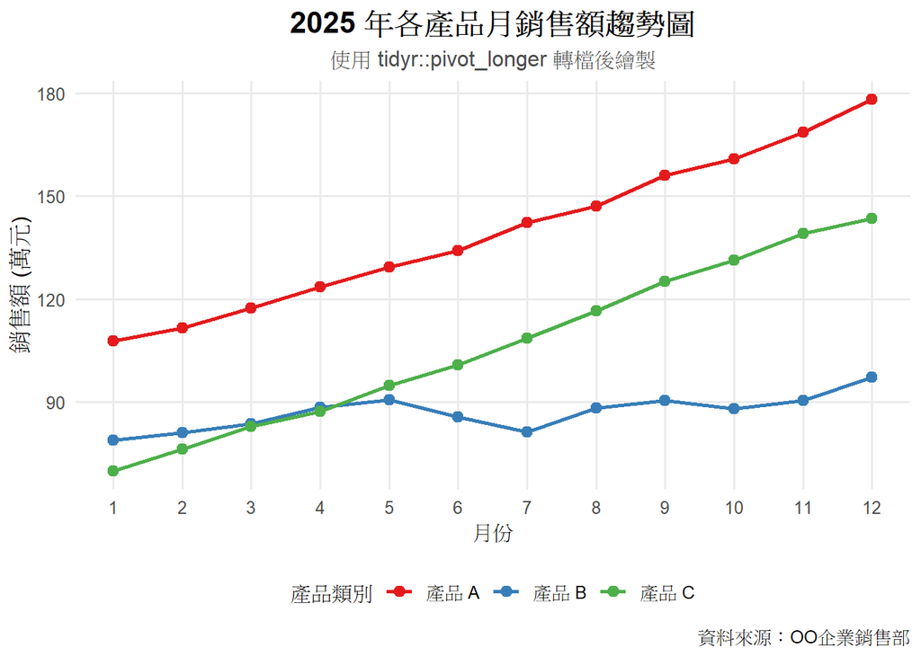

```r
# 4. 結合 ggplot2 繪製多指標折線圖
ggplot(df_sales_long, aes(x = month, y = sales_amount, color = product_type)) +

  # 繪製折線與資料點
  geom_line(linewidth = 1) +
  geom_point(size = 2.5) +

  # 設定 X 軸刻度（顯示 1~12 月）
  scale_x_continuous(breaks = 1:12) +

  # 設定顏色與圖例名稱
  scale_color_brewer(
    palette = "Set1",
    name = "產品類別",
    labels = c("產品 A", "產品 B", "產品 C")
  ) +

  # 標題與軸標籤
  labs(
    title = "2025 年各產品月銷售額趨勢圖",
    subtitle = "使用 tidyr::pivot_longer 轉檔後繪製",
    x = "月份",
    y = "銷售額 (萬元)",
    caption = "資料來源：OO企業銷售部"
  ) +

  # 套用簡潔主題與細節微調
  theme_minimal(base_size = 12) + # 簡潔主題風格(無背景填色, 無外框線, 保留網格線), 基礎文字大小=12
  theme(

    # 將標題置中對齊 (hjust = 0.5)，並加粗
    plot.title = element_text(hjust = 0.5, face = "bold", size = 16),

    # 副標題一起置中對齊
    plot.subtitle = element_text(hjust = 0.5, size = 12, color = "gray30"),

    # 將圖例移至下方
    legend.position = "bottom",

    # 移除次要網格線
    panel.grid.minor = element_blank()
  )
```